# Q4_EDA_FINAL

Brian Wimmer

2022-12-04

```r
# Load libraries
library(ggplot2)
library(tidyverse)
library(psych)
library(dplyr)
library(arsenal)
library(gridExtra)
library(grid)
```

```r
# Load data

# Edy Playlist
edy <- read.csv('/Users/brianwimmer/Desktop/Georgetown/ANLY 511/Final Project/edyPlaylist.csv')
```

```r
# cleaning for EDA purposes

# remove full date from track.album.release_date, keep only the year
edy$track.album.release_date <- substr(edy$track.album.release_date, 0, 4)

# convert track.album.release date to numeric
edy$track.album.release_date <- as.numeric(edy$track.album.release_date)

# doing this may not be necessary, but incase we want it to make numbers seem smaller
# convert duration_ms to duration_s (milliseconds to seconds)
edy$track.duration_ms <- edy$track.duration_ms / 1000

# round up to nearest second
edy$track.duration_ms <- round(edy$track.duration_ms, digits = 0)

# rename duration_ms to duration_s
names(edy)[6] ="track.duration_s"

# create decade column for EDA
edy <- edy %>%
  mutate(
    decade = case_when(
      track.album.release_date >= 1950 & track.album.release_date < 1960    ~ "1950s",
      track.album.release_date >= 1960 & track.album.release_date < 1970  ~ "1960s",
      track.album.release_date >= 1970 & track.album.release_date < 1980  ~ "1970s",
      track.album.release_date >= 1980 & track.album.release_date < 1990   ~ "1980s",
      track.album.release_date >= 1990 & track.album.release_date < 2000   ~ "1990s",
      track.album.release_date >= 2000 & track.album.release_date < 2010   ~ "2000s",
      track.album.release_date >= 2010 & track.album.release_date < 2020   ~ "2010s",
      track.album.release_date >= 2020    ~ "2020s"))
```

```r
# summary statistics of columns 3, 4, 6:15
summary(edy[c(3,4,6:15)])
```

```
##  track.album.release_date track.popularity track.duration_s  danceability
##  Min.   :1954             Min.   : 0.00    Min.   : 70.0    Min.   :0.0793
##  1st Qu.:2001             1st Qu.:39.00    1st Qu.:200.0    1st Qu.:0.4218
##  Median :2009             Median :57.00    Median :234.0    Median :0.5660
##  Mean   :2005             Mean   :52.85    Mean   :246.3    Mean   :0.5464
##  3rd Qu.:2013             3rd Qu.:70.00    3rd Qu.:271.0    3rd Qu.:0.6800
##  Max.   :2022             Max.   :91.00    Max.   :934.0    Max.   :0.9630
##      energy           loudness        speechiness       acousticness
##  Min.   :0.00737   Min.   :-36.111   Min.   :0.02250   Min.   :0.0000151
##  1st Qu.:0.43100   1st Qu.:-10.253   1st Qu.:0.03390   1st Qu.:0.0255250
##  Median :0.68600   Median : -6.923   Median :0.04275   Median :0.1515000
##  Mean   :0.61558   Mean   : -8.620   Mean   :0.06759   Mean   :0.3288883
##  3rd Qu.:0.82450   3rd Qu.: -5.127   3rd Qu.:0.06143   3rd Qu.:0.6382500
##  Max.   :0.99100   Max.   : -1.629   Max.   :0.50800   Max.   :0.9960000
##  instrumentalness     liveness         valence           tempo
##  Min.   :0.00000   Min.   :0.0240   Min.   :0.0256   Min.   : 49.03
##  1st Qu.:0.00000   1st Qu.:0.0904   1st Qu.:0.2565   1st Qu.: 98.72
##  Median :0.00007   Median :0.1210   Median :0.4675   Median :120.30
##  Mean   :0.14069   Mean   :0.1854   Mean   :0.4798   Mean   :119.87
##  3rd Qu.:0.02680   3rd Qu.:0.2290   3rd Qu.:0.7060   3rd Qu.:136.04
##  Max.   :0.96300   Max.   :0.9890   Max.   :0.9810   Max.   :206.68
```

Summary statistics for the playlist variables. From the table above, we can see the minimum, maximum, 1st quartile, 3rd quartile, mean, and median for each of the variables. We will explore the distributions and mean values of some of the variables below. These include the popularity, which is our response variable, as well as some of the other variables that we believe may be the most important predictors.

```r
# EDA for Song Popularity

# color pallete (3rd down with 12 colors): https://stackoverflow.com/questions/57153428/r-plot-color-combinations-that-are-colorblind-accessible

# Histogram for non-audio feature variable (response variable - popularity)
# track.popularity
popularity.hist <- ggplot(edy, aes(x=track.popularity))+
  geom_histogram(binwidth = 5, color="black", fill="#88ccee")+
  labs(title="Histogram Distribution of Song Popularity",x="Popularity", y = "Count")+
  scale_x_continuous(breaks=seq(0,90,10))+
  scale_y_continuous(breaks=seq(0,125,25))+
  annotate("text", x=8, y=100, label= "mean = 53")+
  theme(plot.title = element_text(size = 11, hjust = 0.5), plot.caption = element_text(hjust = 0.5), axis.title = element_text(size = 9))
#popularity.hist

# Boxplot for non-audio feature variable (response variable - popularity)
# track.popularity
popularity.box <- edy %>%
  ggplot(aes(x = track.popularity)) +
  geom_boxplot(fill = '#88ccee') + labs(title = "Boxplot Distribution of Song Popularity")+
  xlab("Popularity")+
  annotate("text", x=12, y=0.35, label= "median = 57")+
  theme(plot.title = element_text(size = 11, hjust = 0.5), plot.caption = element_text(hjust = 0.5), axis.title = element_text(size = 9))
#popularity.box
```

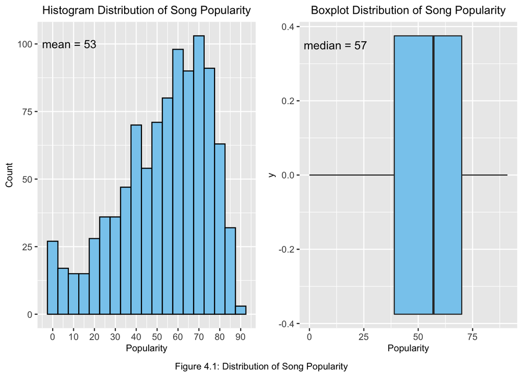

```r
# Display EDA for Song Popularity
# Histogram and Boxplot arranged in 1x2 grid
grid.arrange(popularity.hist, popularity.box, ncol = 2, bottom=textGrob("Figure 4.1: Distribution of Song Popularity", gp = gpar(fontsize = 9)))
```

In Figure 4.1, we can see both a histogram and boxplot for the distribution of song popularity in the playlist. On the left, the histogram shows that the mean popularity for the songs is 53. This indicates that the mean popularity is moderate. We can also see the distribution is slightly left-skewed, indicating that the songs in the playlist might have an overall higher popularity.

On the right, the boplot shows the median popularity for the songs is 57. We can also see that the 1st quartile of songs has a popularity range between 39 and 57, while the 3rd quartile of songs has a popularity range between 57 and 70.

```r
# Histograms for audio feature variables (only 6 we want EDA for in report, others will be in Appendix)
# danceability, energy, loudness, acousticness, valence, & tempo

# color pallete (3rd down with 12 colors): https://stackoverflow.com/questions/57153428/r-plot-color-combinations-that-are-colorblind-accessible

# danceability
dance.hist <- ggplot(edy, aes(x=danceability))+
  geom_histogram(binwidth = .1, color="black", fill="#cc6677")+
  labs(x="Danceability", y = "Count")+
  scale_x_continuous(breaks=c(0.25,0.50,0.75,1.00))+
  scale_y_continuous(breaks=seq(0,200,50))+
  annotate("text", x=0.25, y=200, label= "mean = 0.55",
                  size = 3)+
  theme(plot.title = element_text(hjust = 0.5), axis.title = element_text(size = 9))
#dance.hist

# energy
energy.hist <- ggplot(edy, aes(x=energy))+
  geom_histogram(binwidth = .1, color="black", fill="#aa4499")+
  labs(x="Energy", y = "Count")+
  scale_x_continuous(breaks=c(0.00,0.25,0.50,0.75,1.00))+
  scale_y_continuous(breaks=seq(0,200,50))+
  annotate("text", x=0.15, y=200, label= "mean = 0.62",
                  size = 3)+
  theme(plot.title = element_text(hjust = 0.5), axis.title = element_text(size = 9))
#energy.hist

# loudness
loud.hist <- ggplot(edy, aes(x=loudness))+
  geom_histogram(bins = 10, color="black", fill="#661100")+
  labs(x="Loudness", y = "Count")+
  scale_y_continuous(breaks=seq(0,375,75))+
  annotate("text", x=-28.5, y=375, label= "mean = -8.62",
                  size = 3)+
  theme(plot.title = element_text(hjust = 0.5), axis.title = element_text(size = 9))
#loud.hist

# acousticness
acous.hist <- ggplot(edy, aes(x=acousticness))+
  geom_histogram(binwidth = .1, color="black", fill="#44aa99")+
  labs(x="Acousticness", y = "Count")+
  scale_x_continuous(breaks=c(0.00, 0.25,0.50,0.75,1.00))+
  annotate("text", x=0.83, y=300, label= "mean = 0.33",
                  size = 3)+
  theme(plot.title = element_text(hjust = 0.5), axis.title = element_text(size = 9))
#acous.hist

# valence
val.hist <- ggplot(edy, aes(x=valence))+
  geom_histogram(binwidth = .1, color="black", fill="#999933")+
  labs(x="Valence", y = "Count")+
  scale_y_continuous(breaks=seq(0,125,25))+
  annotate("text", x=0.85, y=125, label= "mean = 0.48",
                  size = 3)+
  theme(plot.title = element_text(hjust = 0.5), axis.title = element_text(size = 9))
#val.hist

# tempo
tempo.hist <- ggplot(edy, aes(x=tempo))+
  geom_histogram(bins = 10, color="black", fill="#888888")+
  labs(x="Tempo", y = "Count")+
  scale_y_continuous(breaks=seq(0,250,50))+
  annotate("text", x=180, y=275, label= "mean = 119.87",
                  size = 3)+
  theme(plot.title = element_text(hjust = 0.5), axis.title = element_text(size = 9))
#tempo.hist
```

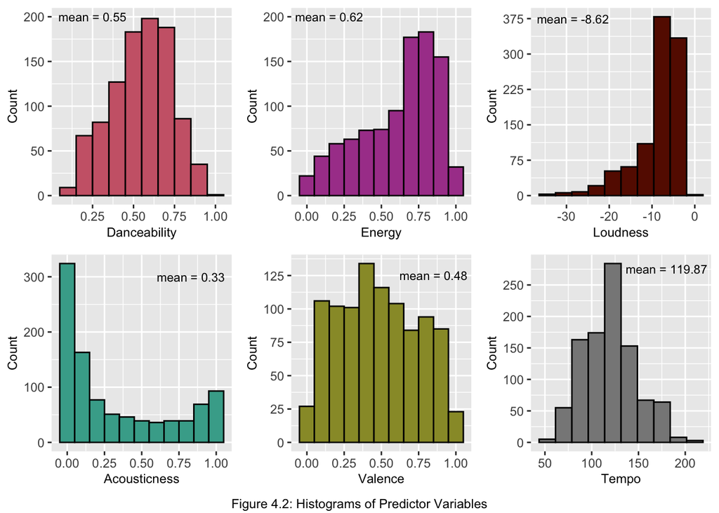

```r
# Display only 6 EDA chosen variables, other 3 variables are in Appendix
# Histograms arranged in 2x3 grid

grid.arrange(dance.hist, energy.hist, loud.hist, acous.hist, val.hist, tempo.hist, ncol = 3, bottom=textGrob("Figure 4.2: Histograms of Predictor Variables", gp = gpar(fontsize = 9)))
```

In Figure 4.2, we can see the distributions of six of our predictor variables. We chose to display these initially, as we believe they may have the most significant effect on our response variable of popularity. It is important to note that we will begin our testing with more predictor variables than shown.

Each histogram plot displays the distribution and mean of each predictor variable: danceability, energy, loudness, acousticness, valence, and tempo.

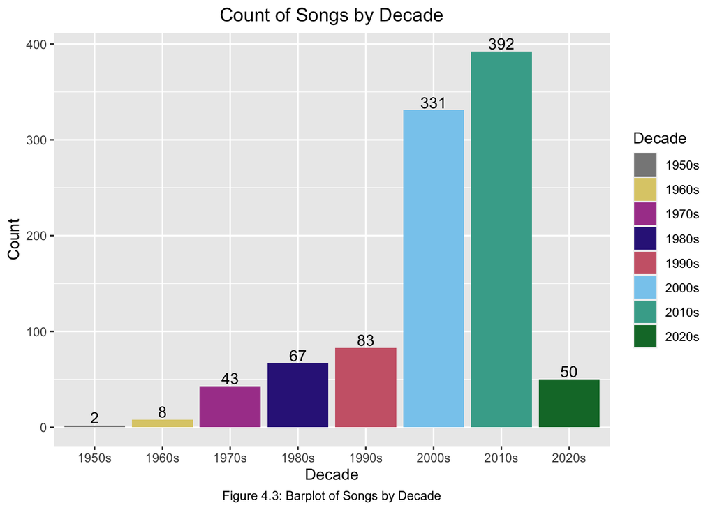

```r
# Bar plot of decade variable, count of songs by decade

# get counts
#table(edy['decade'])
# 1950s 1960s 1970s 1980s 1990s 2000s 2010s 2020s
#    2     8    43    67    83   331   392    50

decade.totals <- data.frame(Decade=c("1950s","1960s","1970s","1980s",
                                     "1990s","2000s","2010s","2020s"),
                     Count=c(2,8,43,67,83,331,392,50))

ggplot(decade.totals, aes(x=Decade, y=Count, fill=Decade)) +
       geom_bar(stat="identity")+
       labs(title="Count of Songs by Decade", x="Decade", y = "Count",
       caption = "Figure 4.3: Barplot of Songs by Decade")+
       scale_fill_manual(values=c("#888888", "#DDCC77", "#AA4499", "#332288",
                                  "#CC6677", "#88CCEE", "#44AA99", "#117733"))+
       theme(plot.title = element_text(hjust = 0.5), plot.caption = element_text(hjust = 0.5))+
       geom_text(aes(label = Count), vjust = -0.2)
```

In Figure 4.3, we can see a count of songs within the playlist by decade released. As we go through our testing, it is important to note that the playlist may not be fully representative of every song on Spotify. Our playlist, for example, has a majority of songs from this millennium. In the barplot, it is clear that the 2000s and 2010s decades were the most represented in the playlist, while the 1950s and 1960s were the least represented. As new music is released, a users’ overall songs and playlist may reflect this change, with newer music making up a higher proportion.

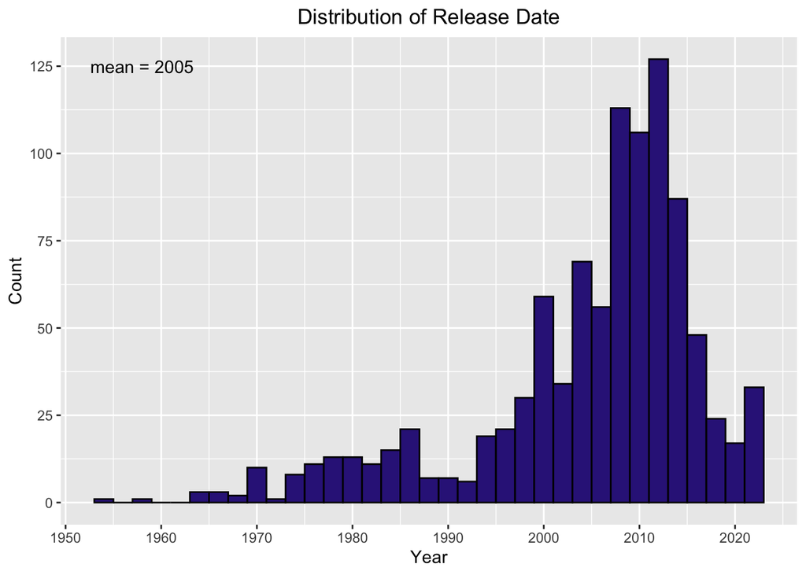

```r
# Appendix - Histograms for non-audio feature variables (track.album.release_date & track.duration_s)

# color pallete (3rd down with 12 colors): https://stackoverflow.com/questions/57153428/r-plot-color-combinations-that-are-colorblind-accessible

# track.album.release_date
date.hist <- ggplot(edy, aes(x=track.album.release_date))+
  geom_histogram(binwidth = 2, color="black", fill="#332288")+
  labs(title="Distribution of Release Date",x="Year", y = "Count")+
  scale_x_continuous(breaks=c(1950,1960,1970,1980,1990,2000,2010,2020))+
  scale_y_continuous(breaks=seq(0,150,25))+
  annotate("text", x=1958, y=125, label= "mean = 2005")+
  theme(plot.title = element_text(hjust = 0.5), plot.caption = element_text(hjust = 0.5))
date.hist
```

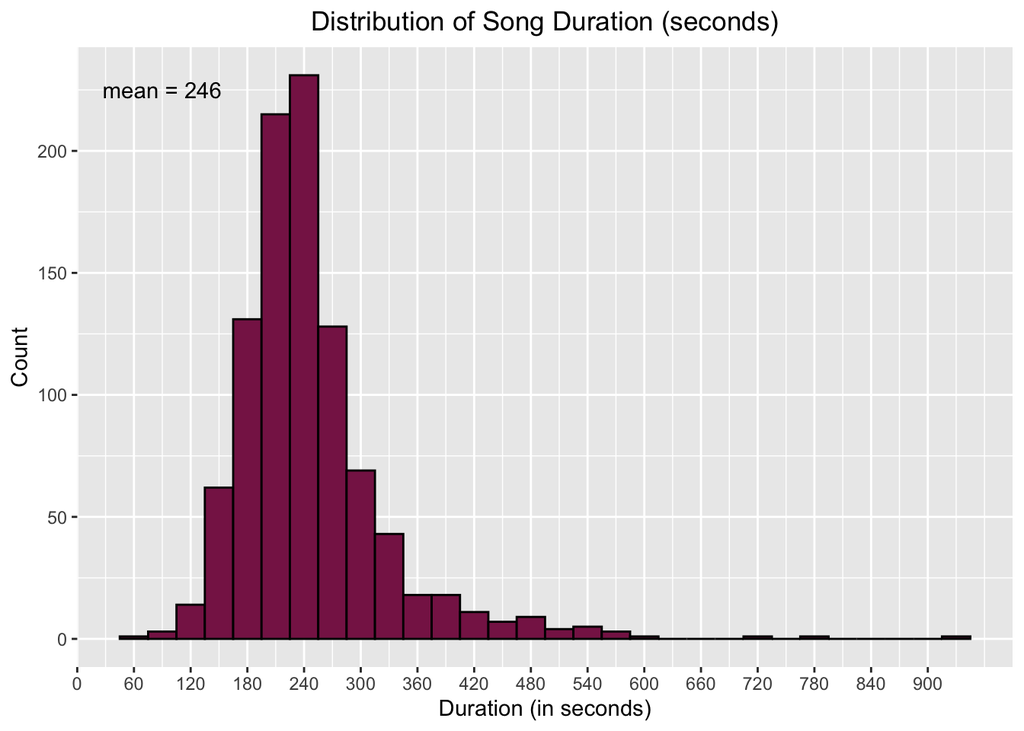

```r
# track.duration_s
duration.hist <- ggplot(edy, aes(x=track.duration_s))+
  geom_histogram(binwidth = 30, color="black", fill="#882255")+
  labs(title="Distribution of Song Duration (seconds)",x="Duration (in seconds)", y = "Count")+
  scale_x_continuous(breaks=seq(0,900,60))+
  scale_y_continuous(breaks=seq(0,250,50))+
  annotate("text", x=90, y=225, label= "mean = 246")+
  theme(plot.title = element_text(hjust = 0.5), plot.caption = element_text(hjust = 0.5))
duration.hist
```

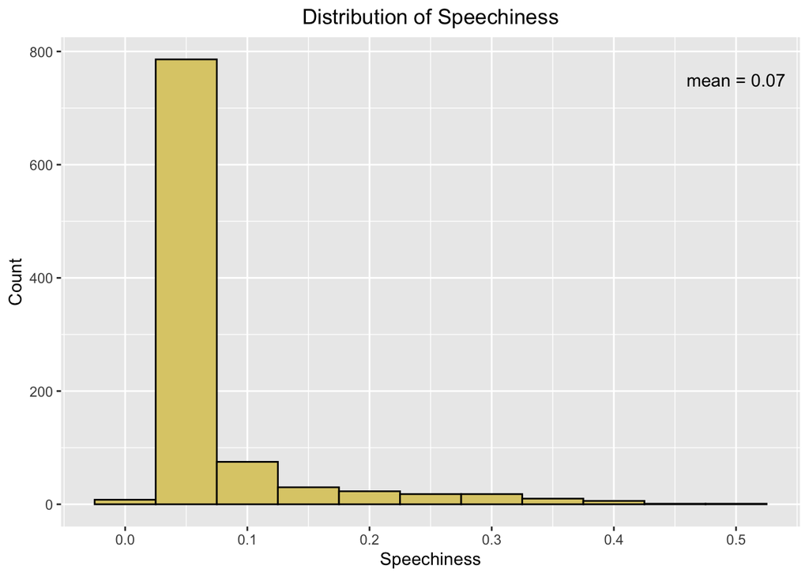

```r
# Appendix - Histograms for audio feature variables
# speechiness, instrumentalness, & liveness

# color pallete (3rd down with 12 colors): https://stackoverflow.com/questions/57153428/r-plot-color-combinations-that-are-colorblind-accessible

# speechiness
speech.hist <- ggplot(edy, aes(x=speechiness))+
  geom_histogram(binwidth = .05, color="black", fill="#ddcc77")+
  labs(title="Distribution of Speechiness",x="Speechiness", y = "Count")+
  scale_x_continuous(breaks=c(0.0, 0.1, 0.2, 0.3, 0.4, 0.5))+
  annotate("text", x=0.5, y=750, label= "mean = 0.07")+
  theme(plot.title = element_text(hjust = 0.5))
speech.hist
```

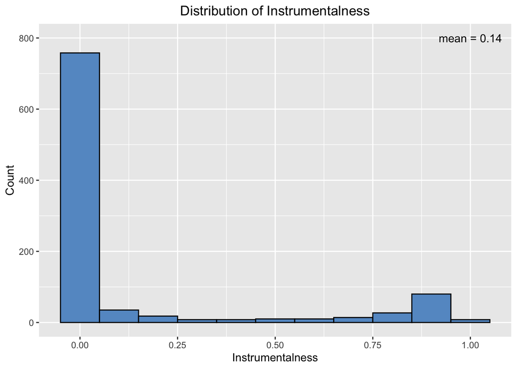

```r
# instrumentalness
instr.hist <- ggplot(edy, aes(x=instrumentalness))+
  geom_histogram(binwidth = .1, color="black", fill="#6699cc")+
  labs(title="Distribution of Instrumentalness",x="Instrumentalness", y = "Count")+
  annotate("text", x=1, y=800, label= "mean = 0.14")+
  theme(plot.title = element_text(hjust = 0.5))
instr.hist
```

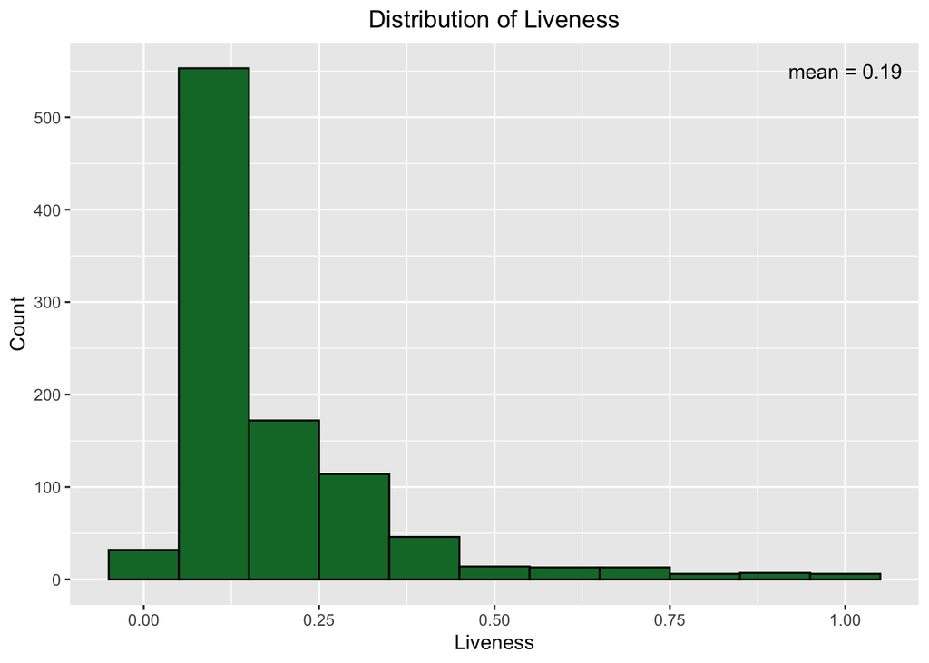

```r
# liveness
live.hist <- ggplot(edy, aes(x=liveness))+
  geom_histogram(binwidth = .1, color="black", fill="#117733")+
  labs(title="Distribution of Liveness",x="Liveness", y = "Count")+
  scale_y_continuous(breaks=seq(0,500,100))+
  annotate("text", x=1, y=550, label= "mean = 0.19")+
  theme(plot.title = element_text(hjust = 0.5))
live.hist
```